# An Introduction to rgm

## Results

We proceed with the diagnostics plots

```r
ps = rgm:::post_processing_rgm(simulated_data = a,results = res)
```

We first observe the convergence of $\beta$ acriss the MCMC iterations

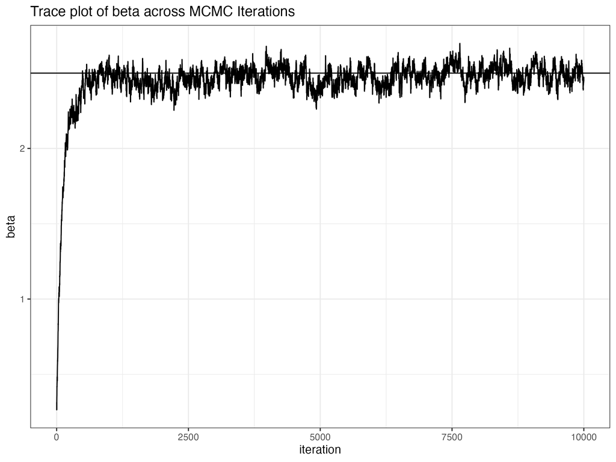

```r
ps$beta_convergence
```

The simulation study results are based on the analysis of the last 2500 MCMC iterations. We compare the true probit probabilities, as derived from Equation 1 using the true values of the parameters, with those calculated using the mean posterior estimates of the parameters $\boldsymbol{\alpha}$, $\beta$, and $\mathbf{c}$.

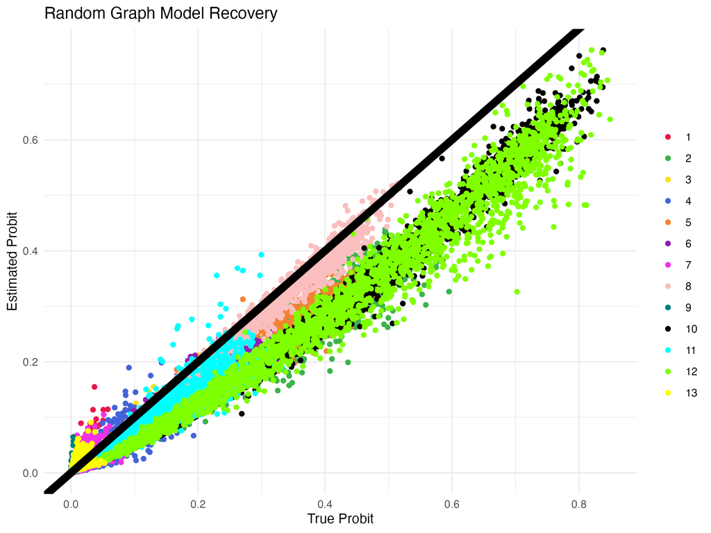

```r
ps$rgm_recovery
```

Next, Receiver Operating Characteristic (ROC) curves compare the recovered graphs with the true graphs for each of the 13 environments. These curves are generated by varying thresholds on the inferred posterior edge probabilities. Different colors represent each of the 13 environments.

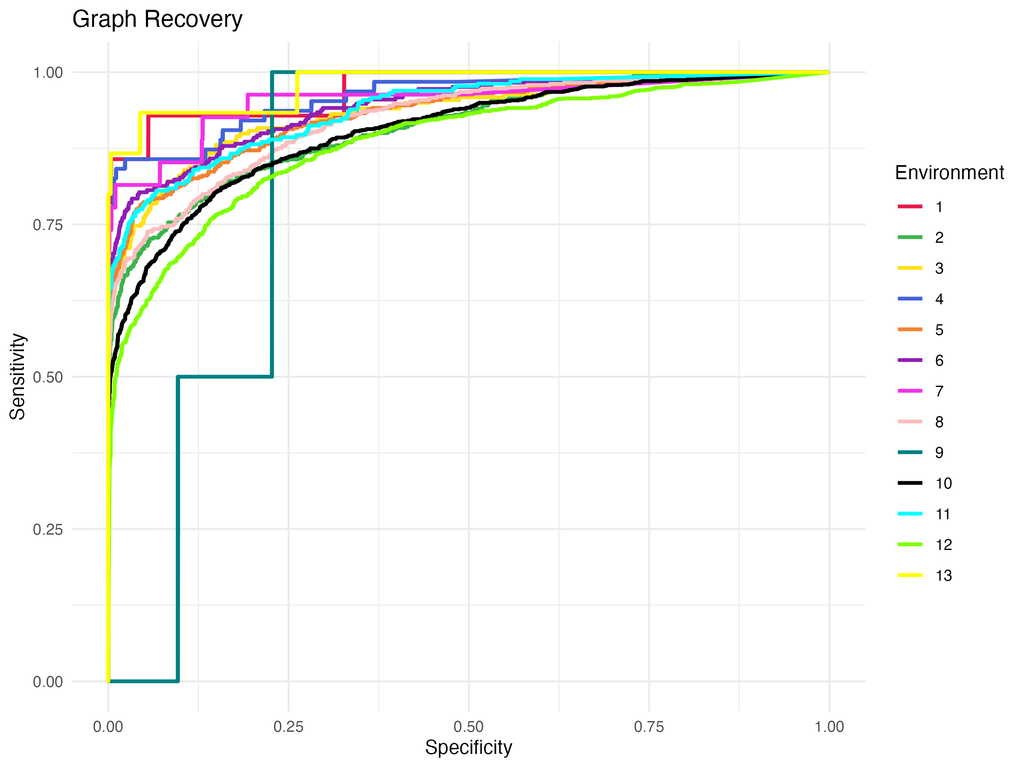

```r
ps$roc_plot
```

The following plot compares the true values of $\alpha_k$ with the mean posterior estimates. The good agreement between the two shows how the procedure is able to recover the right level of sparsity of the inferred graphs in each environment.

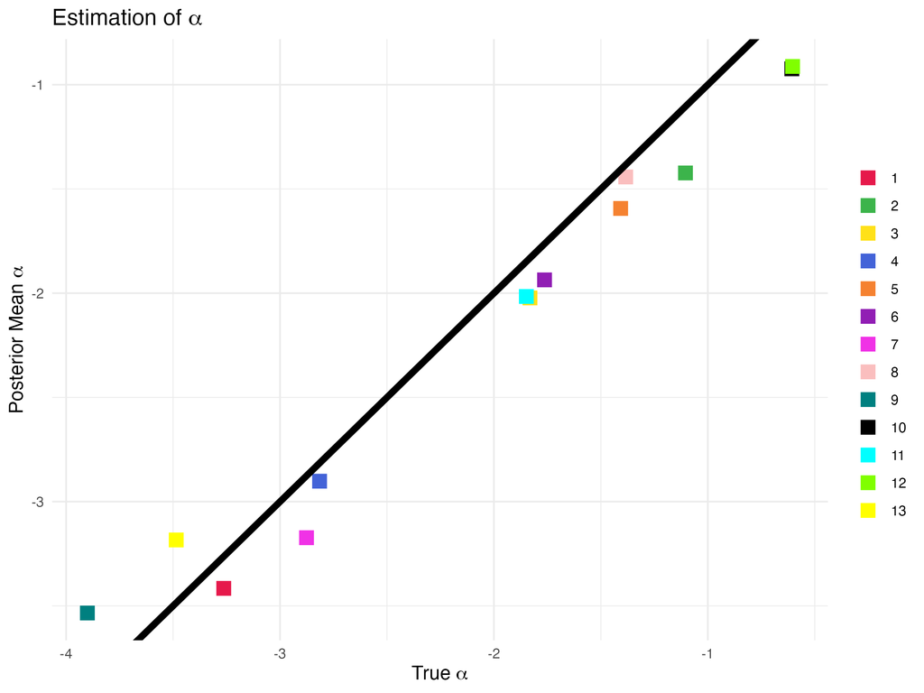

```r
ps$estimation_of_alpha
```

In the next plot, we visualize the posterior distribution of $\beta$ and compare the mean posterior estimate with the true value via vertical lines.

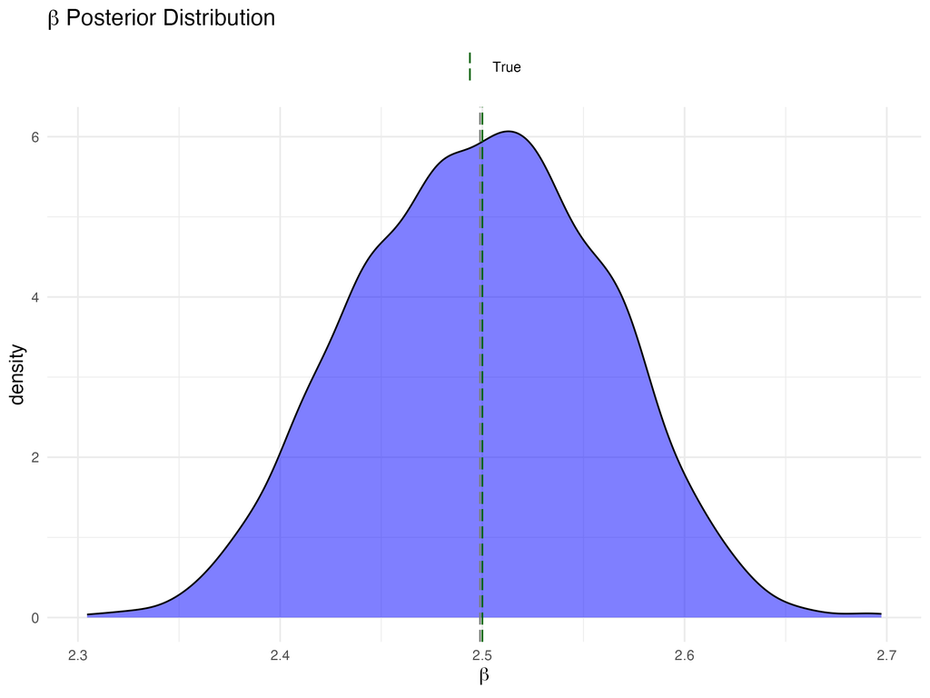

```r
ps$posterior_distribution
```

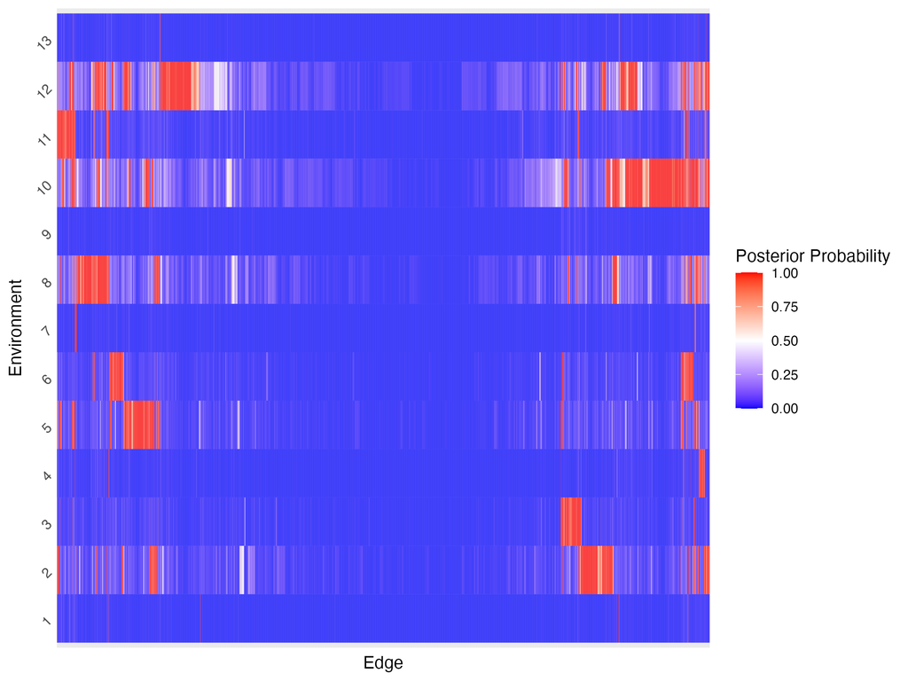

```r
ps$edge_prob
```

The graph shows the sparsity levels of the graphs as well as the similarities between the environments in terms of network structures